# W2_L07_t-test_ANOVA Coding Lecture

# t-test

## Aim

Statistical test to compare the means of two populations.

## Assumptions

- The values from each group follow a **normal distribution**.
- Homogeneous, or equal, variance exists when the standard deviations of samples are approximately equal.
- Scale of measurement applied to the data collected follows a continuous or ordinal scale.
- Data is collected from a representative, randomly selected portion of the total population.

## Load data

```r
# Use dataset 3
# Consider that patients from earth have a different LDL level than patients from venus
ds3 <- read.csv(here::here( "CODING_WEEK_2", "data",  "DATA_FSB_SET_3.csv") , row.names = 1)
summary(ds3)
```

```
##    LDL_levels        Planet            Planet2             Exercise
##  Min.   : 11.55   Length:1500        Length:1500        Min.   :-47.85
##  1st Qu.: 90.02   Class :character   Class :character   1st Qu.: 38.92
##  Median :109.93   Mode  :character   Mode  :character   Median : 61.40
##  Mean   :108.59                                         Mean   : 61.64
##  3rd Qu.:126.89                                         3rd Qu.: 84.27
##  Max.   :191.47                                         Max.   :182.89
##  Sugar_Consumption
##  Min.   :-419.90
##  1st Qu.:  31.31
##  Median :  35.69
##  Mean   :  38.85
##  3rd Qu.:  40.03
##  Max.   :2494.29
```

```r
unique(ds3$Planet2)
```

```
## [1] "Earth"      "Venus"      "Venus_moon"
```

```r
# NO NAs...
```

```r
# install.packages("tidyverse")
# install.packages("corrr")
library(tidyverse)
```

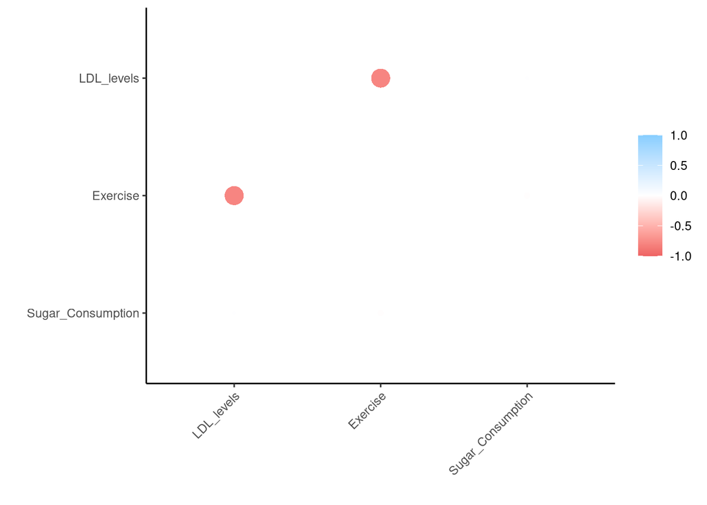

```r
library(corrr)

ds3_corr <- ds3 %>%
  select(-Planet) %>%
  select(-Planet2) %>%
  cor(method = "pearson")

# plot sample correlation structure as heatmap
rplot(ds3_corr) +
  theme(axis.text.x = element_text(angle = 45, hjust = 1))
```

```r
# Visual inspection with box plots shows some difference between the planets
ds3.df <- ds3 %>%
mutate(Planet = factor(Planet)) %>%
mutate(Planet2 = factor(Planet2))

# Let's have a look at the resulting dataframe
glimpse(ds3.df)
```

```
## Rows: 1,500
## Columns: 5
## $ LDL_levels        <dbl> 117.08435, 106.29582, 122.06458, 126.17185, 132.8829…
## $ Planet            <fct> Earth, Earth, Earth, Earth, Earth, Earth, Earth, Ear…
## $ Planet2           <fct> Earth, Earth, Earth, Earth, Earth, Earth, Earth, Ear…
## $ Exercise          <dbl> 35.225465, 86.118299, 75.440539, 39.336172, 23.61452…
## $ Sugar_Consumption <dbl> 33.07423, 35.76640, 30.14053, 30.96687, 39.04388, 28…
```

```r
ds3.df %>%
group_by(Planet) %>%
summarise(
count_planet = n(),
mean_LDL = mean(LDL_levels, na.rm = TRUE),
sd_LDL = sd(LDL_levels, na.rm = TRUE)
)
```

```
## # A tibble: 2 × 4
##   Planet count_planet mean_LDL sd_LDL
##   <fct>         <int>    <dbl>  <dbl>
## 1 Earth           781    118.    25.2
## 2 Venus           719     98.3   25.4
```

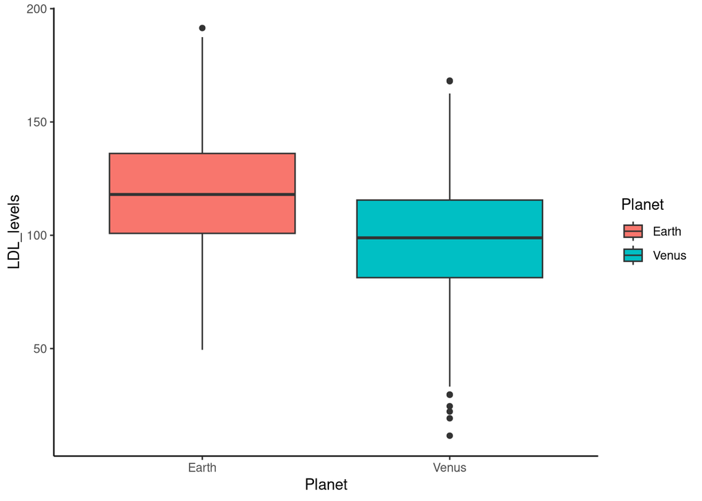

```r
plt <- ggplot(ds3.df, aes(x = Planet, y = LDL_levels, fill = Planet)) +
geom_boxplot() +
theme_classic()
plt
```

## Analyze assumptions

Before we can employ a t-Test, we have to assess whether the fundamental assumptions hold.

### Asumption 1: *each group follows a normal distribution*.

A histogram provides a useful visualization. Let’s look at LDL level histogram:

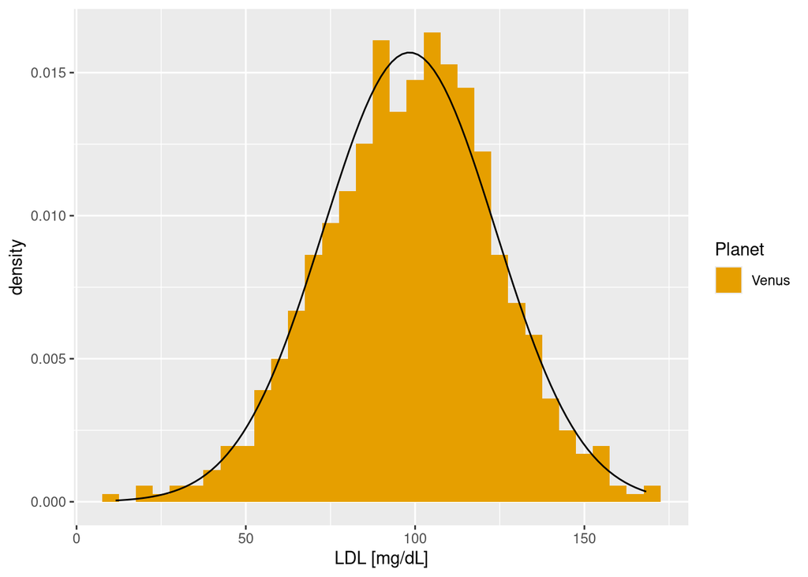

```r
# focus on Venus, since we can hypothesize that there is a difference between the planets
planet <- 'Venus'

# ggplot2 allows to easily fit a normal distribution on our data for a visual assessment
plt <- ds3 %>%
filter(Planet == planet) %>%
    ggplot() +
    geom_histogram(aes(x = LDL_levels, y = ..density.., fill = Planet), binwidth = 5) +
    xlab("LDL [mg/dL]") +
    stat_function(fun = dnorm,
                  args = list(mean = mean(ds3$LDL_levels[ds3$Planet == planet]),
                              sd = sd(ds3$LDL_levels[ds3$Planet == planet]))) +
scale_fill_manual(values=c("#E69F00", "#56B4E9","#999999"))
plt
```

But visual assessment can be deceiving. A more precise way is a quantile-quantile plot:

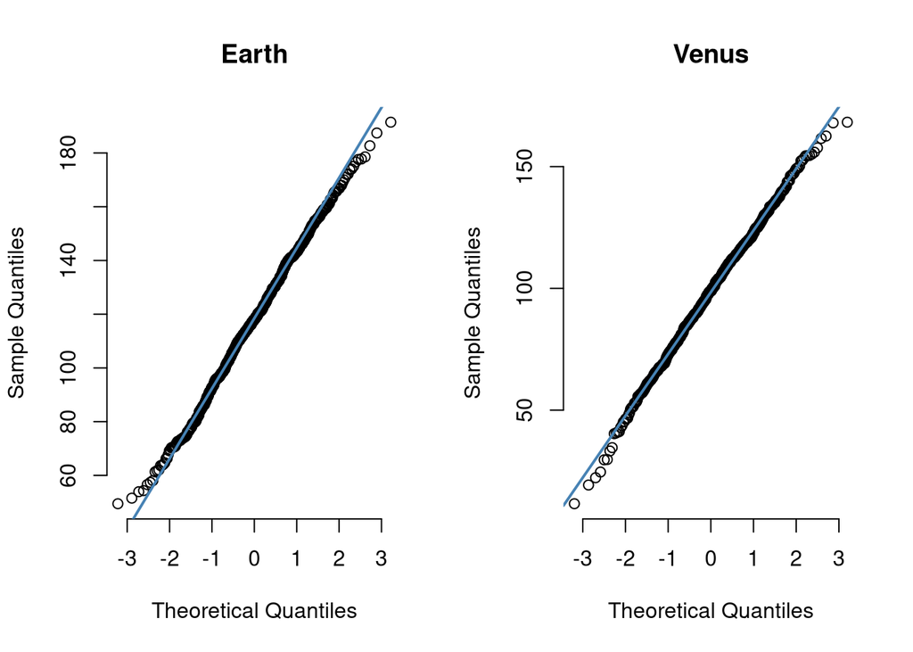

```r
options(repr.plot.width = 7, repr.plot.height = 4)
par(mfrow = c(1,2), bg = 'white')
# For Earth
qqnorm(ds3$LDL_levels[ds3$Planet == 'Earth'], pch = 1, frame = FALSE, main = 'Earth')
qqline(ds3$LDL_levels[ds3$Planet == 'Earth'], col = "steelblue", lwd = 2)

# For Venus
qqnorm(ds3$LDL_levels[ds3$Planet == 'Venus'], pch = 1, frame = FALSE, main = 'Venus')
qqline(ds3$LDL_levels[ds3$Planet == 'Venus'], col = "steelblue", lwd = 2)
```

```r
shapiro.test(ds3$LDL_levels[ds3$Planet == 'Earth'])
```

```
##
##  Shapiro-Wilk normality test
##
## data:  ds3$LDL_levels[ds3$Planet == "Earth"]
## W = 0.99748, p-value = 0.2782
```

```r
shapiro.test(ds3$LDL_levels[ds3$Planet == 'Venus'])
```

```
##
##  Shapiro-Wilk normality test
##
## data:  ds3$LDL_levels[ds3$Planet == "Venus"]
## W = 0.99781, p-value = 0.4756
```

### Asumption 2: each group has the same variance.

The Bartlett test can be used to determine if the variance is similar between two samples.

```r
ldl_vs_planet.varTest <- bartlett.test(LDL_levels ~ Planet, data = ds3)
ldl_vs_planet.varTest
```

```
##
##  Bartlett test of homogeneity of variances
##
## data:  LDL_levels by Planet
## Bartlett's K-squared = 0.034077, df = 1, p-value = 0.8535
```

### Asumption 3: Independence

The third assumption is independence of samples from each other. This assumption needs to be investigated in the context of the experimental design. Let us assume, individuals are coming from different families, and there is no bias towards selection (e.g. not a bias towards younger).

## Running the t-test

```r
# first without variance-equality option
ldl.vs.planet.ttest <-  t.test(LDL_levels ~ Planet, data=ds3)
ldl.vs.planet.ttest
```

```
##
##  Welch Two Sample t-test
##
## data:  LDL_levels by Planet
## t = 15.044, df = 1486.1, p-value < 2.2e-16
## alternative hypothesis: true difference in means between group Earth and group Venus is not equal to 0
## 95 percent confidence interval:
##  17.12100 22.25508
## sample estimates:
## mean in group Earth mean in group Venus
##           118.03200            98.34396
```

```r
# the actual p-value
signif(ldl.vs.planet.ttest$p.value, digits=3)
```

```
## [1] 1.02e-47
```

```r
# second with variance-equality option, since we tested that
ldl.vs.planet.ttest.2 <-  t.test(LDL_levels ~ Planet, data=ds3, var.equal = TRUE)
ldl.vs.planet.ttest.2
```

```
##
##  Two Sample t-test
##
## data:  LDL_levels by Planet
## t = 15.049, df = 1498, p-value < 2.2e-16
## alternative hypothesis: true difference in means between group Earth and group Venus is not equal to 0
## 95 percent confidence interval:
##  17.12173 22.25435
## sample estimates:
## mean in group Earth mean in group Venus
##           118.03200            98.34396
```

```r
# the actual p-value
signif(ldl.vs.planet.ttest.2$p.value, digits=3)
```

```
## [1] 9.09e-48
```

As a result, considering that we set a theshold for significance at 0.01, we can reject the null hypothesis, and we will consider the two populations to have a different mean.

# ANOVA

Let us review the comparisons between means when instead of two groups, we have three groups.

## Comparing the means.

```r
ds3 %>%
group_by(Planet2) %>%
summarise(
count_planets = n(),
mean_time = mean(LDL_levels, na.rm = TRUE),
sd_time = sd(LDL_levels, na.rm = TRUE)
)
```

```
## # A tibble: 3 × 4
##   Planet2    count_planets mean_time sd_time
##   <chr>              <int>     <dbl>   <dbl>
## 1 Earth                781     118.     25.2
## 2 Venus                364     102.     24.6
## 3 Venus_moon           355      94.7    25.7
```

## Comparing the empirical distributions between the planets using boxplots

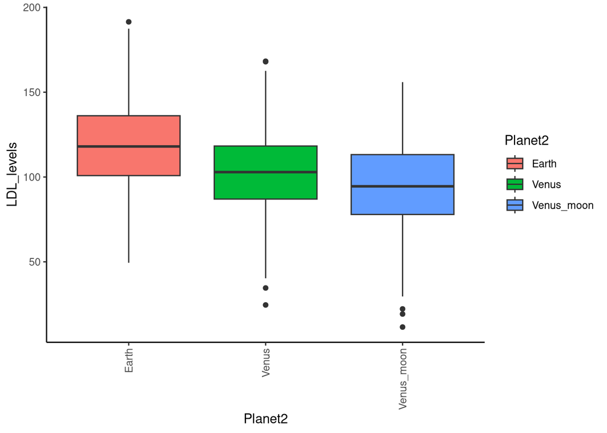

```r
#Lets look at the
plt <- ggplot(ds3.df, aes(x = Planet2, y = LDL_levels, fill = Planet2)) +
geom_boxplot() +
theme_classic() +
theme(axis.text.x = element_text(angle = 90, vjust = 0.5, hjust=1))
plt
```

## Running the ANOVA test

```r
# Now for the systematic analysis using a one way ANOVA
anova_one_way <- aov(Exercise ~ Planet2, data = ds3)
summary(anova_one_way)
```

```
##               Df  Sum Sq Mean Sq F value Pr(>F)
## Planet2        2  109558   54779   52.96 <2e-16 ***
## Residuals   1497 1548308    1034
## ---
## Signif. codes:  0 '***' 0.001 '**' 0.01 '*' 0.05 '.' 0.1 ' ' 1
```

## Post-hoc analysis

```r
TukeyHSD(anova_one_way, ordered = TRUE)
```

```
##   Tukey multiple comparisons of means
##     95% family-wise confidence level
##     factor levels have been ordered
##
## Fit: aov(formula = Exercise ~ Planet2, data = ds3)
##
## $Planet2
##                      diff        lwr      upr     p adj
## Venus-Earth      14.18439  9.3961091 18.97267 0.0000000
## Venus_moon-Earth 19.34014 14.5106358 24.16964 0.0000000
## Venus_moon-Venus  5.15575 -0.4722292 10.78373 0.0805397
```

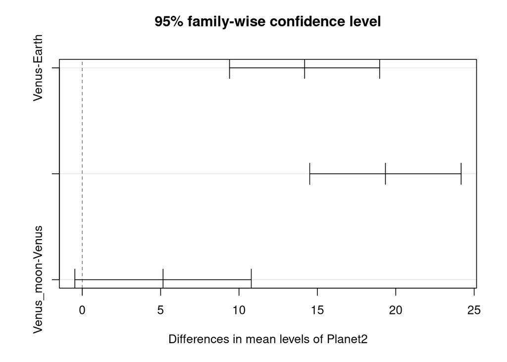

```r
plot(TukeyHSD(anova_one_way, ordered = TRUE))
```